# Build and deploy a stroke prediction model using R

**BISHAL DHUNGANA**

05-01-2024

**ABOUT DATA ANALYSIS REPORT**

This RMarkdown file contains the report of the data analysis done for the project on building and deploying a stroke prediction model in R. It contains analysis such as data exploration, summary statistics, and building the prediction models.

**DATA DESCRIPTION:**

According to the World Health Organization (WHO), STROKE IS THE 2ND LEADING CAUSE OF DEATH GLOBALLY, RESPONSIBLE FOR APPROXIMATELY 11% OF TOTAL DEATHS.

This dataset is used to predict whether a patient is likely to get stroke based on the input parameters like gender, age, various diseases, and smoking status. Each row in the data provides relevant information about the patient.

**TASK ONE: IMPORT DATA AND DATA PREPROCESSING** Load data and install packages

```r
packages <- c("tidyverse", "lubridate", "ggplot2", "dplyr", "caret", "randomForest", "skimr", "gridExtra", "caTools", "corrplot", "ggcorrplot", "naniar")

# Install and load required packages
for (pkg in packages) {
  if (!require(pkg, character.only = TRUE)) {
    install.packages(pkg)
    library(pkg, character.only = TRUE)
  }
}
```

```r
Data_Stroke <- read.csv('healthcare-dataset-stroke-data.csv')
summary(Data_Stroke)
```

```
       id           gender               age         hypertension     heart_disease     ever_married        work_type
 Min.   :   67   Length:5110        Min.   : 0.08   Min.   :0.00000   Min.   :0.00000   Length:5110        Length:5110
 1st Qu.:17741   Class :character   1st Qu.:25.00   1st Qu.:0.00000   1st Qu.:0.00000   Class :character   Class :character
 Median :36932   Mode  :character   Median :45.00   Median :0.00000   Median :0.00000   Mode  :character   Mode  :character
 Mean   :36518                      Mean   :43.23   Mean   :0.09746   Mean   :0.05401
 3rd Qu.:54682                      3rd Qu.:61.00   3rd Qu.:0.00000   3rd Qu.:0.00000
 Max.   :72940                      Max.   :82.00   Max.   :1.00000   Max.   :1.00000
 Residence_type     avg_glucose_level     bmi            smoking_status         stroke
 Length:5110        Min.   : 55.12    Length:5110        Length:5110        Min.   :0.00000
 Class :character   1st Qu.: 77.25    Class :character   Class :character   1st Qu.:0.00000
 Mode  :character   Median : 91.89    Mode  :character   Mode  :character   Median :0.00000
                    Mean   :106.15                                          Mean   :0.04873
                    3rd Qu.:114.09                                          3rd Qu.:0.00000
                    Max.   :271.74                                          Max.   :1.00000
```

```r
glimpse(Data_Stroke)
```

```
Rows: 5,110
Columns: 12
$ id                <int> 9046, 51676, 31112, 60182, 1665, 56669, 53882, 10434, 27419, 60491, 12109, 12095, 12175, 8213, 5317,…
$ gender            <chr> "Male", "Female", "Male", "Female", "Female", "Male", "Male", "Female", "Female", "Female", "Female"…
$ age               <dbl> 67, 61, 80, 49, 79, 81, 74, 69, 59, 78, 81, 61, 54, 78, 79, 50, 64, 75, 60, 57, 71, 52, 79, 82, 71, …
$ hypertension      <int> 0, 0, 0, 0, 1, 0, 1, 0, 0, 0, 1, 0, 0, 0, 0, 1, 0, 1, 0, 0, 0, 1, 0, 0, 0, 0, 0, 0, 0, 0, 1, 0, 1, 0…
$ heart_disease     <int> 1, 0, 1, 0, 0, 0, 1, 0, 0, 0, 0, 1, 0, 1, 1, 0, 1, 0, 0, 1, 0, 0, 0, 1, 0, 0, 0, 0, 1, 0, 0, 0, 0, 1…
$ ever_married      <chr> "Yes", "Yes", "Yes", "Yes", "Yes", "Yes", "Yes", "No", "Yes", "Yes", "Yes", "Yes", "Yes", "Yes", "Ye…
$ work_type         <chr> "Private", "Self-employed", "Private", "Private", "Self-employed", "Private", "Private", "Private", …
$ Residence_type    <chr> "Urban", "Rural", "Rural", "Urban", "Rural", "Urban", "Rural", "Urban", "Rural", "Urban", "Rural", "…
$ avg_glucose_level <dbl> 228.69, 202.21, 105.92, 171.23, 174.12, 186.21, 70.09, 94.39, 76.15, 58.57, 80.43, 120.46, 104.51, 2…
$ bmi               <chr> "36.6", "N/A", "32.5", "34.4", "24", "29", "27.4", "22.8", "N/A", "24.2", "29.7", "36.8", "27.3", "N…
$ smoking_status    <chr> "formerly smoked", "never smoked", "never smoked", "smokes", "never smoked", "formerly smoked", "nev…
$ stroke            <int> 1, 1, 1, 1, 1, 1, 1, 1, 1, 1, 1, 1, 1, 1, 1, 1, 1, 1, 1, 1, 1, 1, 1, 1, 1, 1, 1, 1, 1, 1, 1, 1, 1, 1…
```

```r
skim(Data_Stroke)
```

```
── Data Summary ────────────────────────
                           Values
Name                       Data_Stroke
Number of rows             5110
Number of columns          12
_______________________
Column type frequency:
  character                6
  numeric                  6
________________________
Group variables            None
```

|  | skim_variable | n_missing | complete_rate | min | max | empty | n_unique | whitespace |
| --- | --- | --- | --- | --- | --- | --- | --- | --- |
| 1 | gender | 0 | 1 | 4 | 6 | 0 | 3 | 0 |
| 2 | ever_married | 0 | 1 | 2 | 3 | 0 | 2 | 0 |
| 3 | work_type | 0 | 1 | 7 | 13 | 0 | 5 | 0 |
| 4 | Residence_type | 0 | 1 | 5 | 5 | 0 | 2 | 0 |
| 5 | bmi | 0 | 1 | 2 | 4 | 0 | 419 | 0 |
| 6 | smoking_status | 0 | 1 | 6 | 15 | 0 | 4 | 0 |

|  | skim_variable | n_missing | complete_rate | mean | sd | p0 | p25 | p50 | p75 | p100 | hist |
| --- | --- | --- | --- | --- | --- | --- | --- | --- | --- | --- | --- |
| 1 | id | 0 | 1 | 3.651783e+04 | 2.116172e+04 | 67.00 | 17741.250 | 36932.000 | 54682.00 | 72940.00 | ▇▇▇▇▇ |
| 2 | age | 0 | 1 | 4.322661e+01 | 2.261265e+01 | 0.08 | 25.000 | 45.000 | 61.00 | 82.00 | ▅▆▇▇▆ |
| 3 | hypertension | 0 | 1 | 9.745597e-02 | 2.966067e-01 | 0.00 | 0.000 | 0.000 | 0.00 | 1.00 | ▇▁▁▁▁ |
| 4 | heart_disease | 0 | 1 | 5.401174e-02 | 2.260630e-01 | 0.00 | 0.000 | 0.000 | 0.00 | 1.00 | ▇▁▁▁▁ |
| 5 | avg_glucose_level | 0 | 1 | 1.061477e+02 | 4.528356e+01 | 55.12 | 77.245 | 91.885 | 114.09 | 271.74 | ▇▃▁▁▁ |
| 6 | stroke | 0 | 1 | 4.872798e-02 | 2.153199e-01 | 0.00 | 0.000 | 0.000 | 0.00 | 1.00 | ▇▁▁▁▁ |

```r
miss_scan_count(data = Data_Stroke, search = list("Unknown","N/A","Other"))
```

| Variable | n |
| --- | --- |
| id | 0 |
| gender | 1 |
| age | 0 |
| hypertension | 0 |
| heart_disease | 0 |
| ever_married | 0 |
| work_type | 0 |
| Residence_type | 0 |
| avg_glucose_level | 0 |
| bmi | 201 |

[output cut: 2 more lines]

```r
##Convert NA to median in BMI
Data_Stroke$bmi <- as.numeric(Data_Stroke$bmi)
```

```r
idx <- complete.cases(Data_Stroke)
bmi_idx <- is.na(Data_Stroke$bmi)
median_bmi <- median(Data_Stroke$bmi, na.rm = TRUE)

Data_Stroke[bmi_idx,]$bmi <- median_bmi
colSums(is.na(Data_Stroke))
```

```
               id            gender               age      hypertension     heart_disease      ever_married         work_type
                0                 0                 0                 0                 0                 0                 0
   Residence_type avg_glucose_level               bmi    smoking_status            stroke
                0                 0                 0                 0                 0
```

```r
##Check duplicates
sum(duplicated(Data_Stroke))
```

```
[1] 0
```

```r
colSums(Data_Stroke == 'N/A')
```

```
               id            gender               age      hypertension     heart_disease      ever_married         work_type
                0                 0                 0                 0                 0                 0                 0
   Residence_type avg_glucose_level               bmi    smoking_status            stroke
                0                 0                 0                 0                 0
```

```r
colSums(Data_Stroke == '')
```

```
               id            gender               age      hypertension     heart_disease      ever_married         work_type
                0                 0                 0                 0                 0                 0                 0
   Residence_type avg_glucose_level               bmi    smoking_status            stroke
                0                 0                 0                 0                 0
```

```r
Data_Stroke %>% count(gender)
```

| gender | n |
| --- | --- |
| Female | 2994 |
| Male | 2115 |
| Other | 1 |

```r
##Remove ID and filter out 'Other' values in Gender
Data_Stroke <- Data_Stroke %>%
  select(-c(id)) %>%
  filter(gender != "Other")
str(Data_Stroke)
```

```
'data.frame':   5109 obs. of  11 variables:
 $ gender           : chr  "Male" "Female" "Male" "Female" ...
 $ age              : num  67 61 80 49 79 81 74 69 59 78 ...
 $ hypertension     : int  0 0 0 0 1 0 1 0 0 0 ...
 $ heart_disease    : int  1 0 1 0 0 0 1 0 0 0 ...
 $ ever_married     : chr  "Yes" "Yes" "Yes" "Yes" ...
 $ work_type        : chr  "Private" "Self-employed" "Private" "Private" ...
 $ Residence_type   : chr  "Urban" "Rural" "Rural" "Urban" ...
 $ avg_glucose_level: num  229 202 106 171 174 ...
 $ bmi              : num  36.6 28.1 32.5 34.4 24 29 27.4 22.8 28.1 24.2 ...
 $ smoking_status   : chr  "formerly smoked" "never smoked" "never smoked" "smokes" ...
 $ stroke           : int  1 1 1 1 1 1 1 1 1 1 ...
```

```r
##Convert non-numeric variables to factors
Data_Stroke$stroke <- factor(Data_Stroke$stroke, levels = c(0,1), labels = c("No", "Yes"))
Data_Stroke$hypertension <- factor(Data_Stroke$hypertension, levels = c(0,1), labels = c("No", "Yes"))
Data_Stroke$heart_disease <- factor(Data_Stroke$heart_disease, levels = c(0,1), labels = c("No", "Yes"))
```

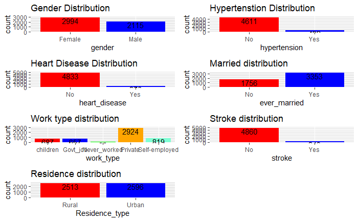

```r
d1 <- Data_Stroke %>%
  ggplot(aes(x = gender, fill = gender)) +
  geom_bar(fill = c("red", "blue")) +
  ggtitle("Gender Distribution") +
  geom_text(aes(label=..count..), stat = "Count", vjust = 1.0)

d2 <- Data_Stroke %>%
  ggplot(aes(x = hypertension, fill = hypertension)) +
  geom_bar(fill = c("red", "blue")) +
  ggtitle("Hypertenstion Distribution") +
  geom_text(aes(label=..count..), stat = "Count", vjust = 1.0)


d3 <- Data_Stroke %>%
  ggplot(aes(x = heart_disease, fill = heart_disease)) +
  geom_bar(fill = c("red", "blue")) +
  ggtitle("Heart Disease Distribution") +
  geom_text(aes(label=..count..), stat = "Count", vjust = 1.0)

d4 <- Data_Stroke %>%
  ggplot(aes(x = ever_married, fill = ever_married)) +
  geom_bar(fill = c("red","blue")) +
  ggtitle("Married distribution") +
  geom_text(aes(label=..count..), stat = "Count", vjust = 1.0)

d5 <- Data_Stroke %>%
  ggplot(aes(x = work_type, fill = work_type)) +
  geom_bar(fill = c("red", "blue","green","orange","aquamarine")) +
  ggtitle("Work type distribution") +
  geom_text(aes(label=..count..), stat = "Count", vjust = 1.0)

d6 <- Data_Stroke %>%
  ggplot(aes(x = stroke, fill = stroke)) +
  geom_bar(fill = c("red", "blue")) +
  ggtitle("Stroke distribution") +
  geom_text(aes(label=..count..), stat = "Count", vjust = 1.0)

d7 <- Data_Stroke %>%
  ggplot(aes(x = Residence_type, fill = Residence_type)) +
  geom_bar(fill = c("red", "blue")) +
  ggtitle("Residence distribution") +
  geom_text(aes(label=..count..), stat = "Count", vjust = 1.0)


grid.arrange(d1,d2,d3,d4,d5,d6,d7, ncol=2)
```

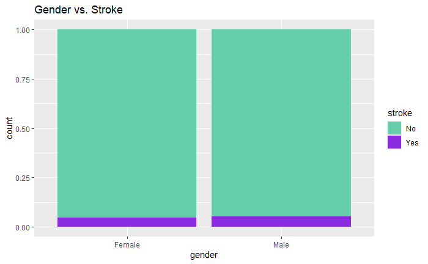

```r
Data_Stroke %>%
  ggplot(aes(x = gender, fill = stroke)) +
  geom_bar(position = "fill") +
  scale_fill_manual(values=c("aquamarine3",
                             "blueviolet")) +
  ggtitle("Gender vs. Stroke")
```

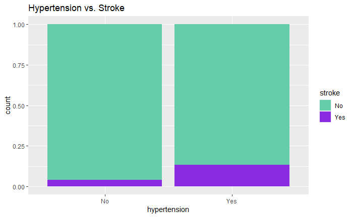

```r
Data_Stroke %>%
  ggplot(aes(x = hypertension, fill = stroke)) +
  geom_bar(position = "fill") +
  scale_fill_manual(values=c("aquamarine3",
                             "blueviolet")) +
  ggtitle("Hypertension vs. Stroke")
```

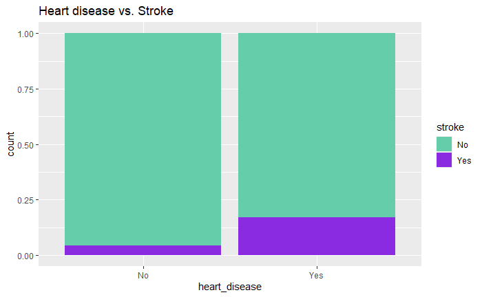

```r
Data_Stroke %>%
  ggplot(aes(x = heart_disease, fill = stroke)) +
  geom_bar(position = "fill") +
  scale_fill_manual(values=c("aquamarine3",
                             "blueviolet")) +
  ggtitle("Heart disease vs. Stroke")
```

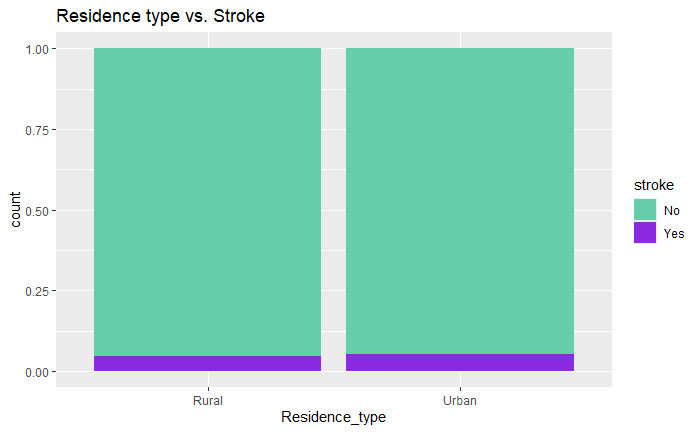

```r
Data_Stroke %>%
  ggplot(aes(x = Residence_type, fill = stroke)) +
  geom_bar(position = "fill") +
  scale_fill_manual(values=c("aquamarine3",
                             "blueviolet")) +
  ggtitle("Residence type vs. Stroke")
```

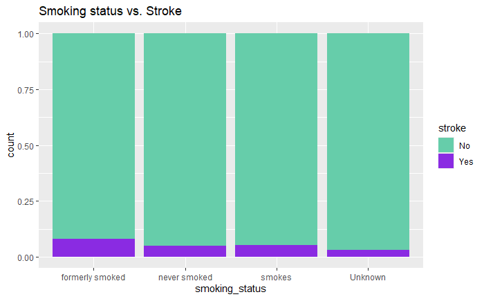

```r
Data_Stroke %>%
  ggplot(aes(x = smoking_status, fill = stroke)) +
  geom_bar(position = "fill") +
  scale_fill_manual(values=c("aquamarine3",
                             "blueviolet")) +
  ggtitle("Smoking status vs. Stroke")
```

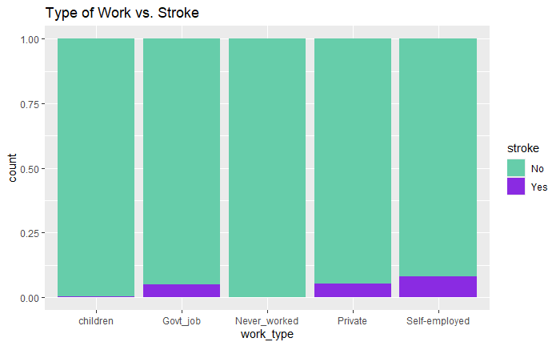

```r
Data_Stroke %>%
  ggplot(aes(x = work_type, fill = stroke)) +
  geom_bar(position = "fill") +
  scale_fill_manual(values=c("aquamarine3",
                             "blueviolet"
                             )) +
  ggtitle("Type of Work vs. Stroke")
```

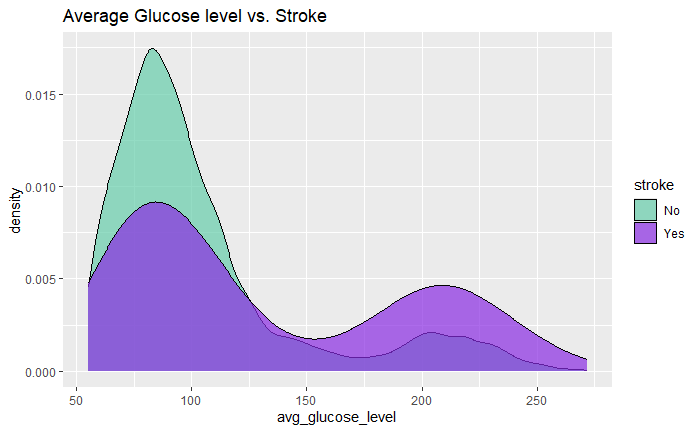

```r
Data_Stroke %>%
  ggplot(aes(x = avg_glucose_level, fill = stroke)) +
  geom_density(alpha = 0.7) +
  scale_fill_manual(values=c("aquamarine3",
                             "blueviolet"
  )) +
  ggtitle("Average Glucose level vs. Stroke")
```

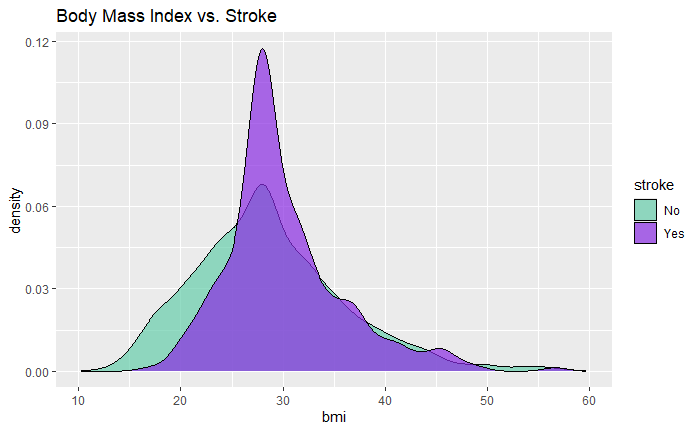

```r
Data_Stroke %>% filter(between(bmi, 0, 60)) %>%
  ggplot(aes(x = bmi, fill = stroke)) +
  geom_density(alpha = 0.7) +
  scale_fill_manual(values=c("aquamarine3",
                             "blueviolet"
  )) +
  ggtitle("Body Mass Index vs. Stroke")
```

**TASK THREE: EVALUATE AND SELECT PREDICTION MODELS**

```r
sample.split(Data_Stroke$stroke,SplitRatio = 0.8)->split_tag
train<-subset(Data_Stroke,split_tag==TRUE)
test<-subset(Data_Stroke,split_tag==FALSE)
dim(train)
```

```
[1] 4087   11
```

```r
dim(test)
```

```
[1] 1022   11
```

```r
set.seed(123)
rf <- randomForest(formula = stroke~.,data = train)
rf
```

```
Call:
 randomForest(formula = stroke ~ ., data = train)
               Type of random forest: classification
                     Number of trees: 500
No. of variables tried at each split: 3

        OOB estimate of  error rate: 5.02%
Confusion matrix:
      No Yes class.error
No  3881   7 0.001800412
Yes  198   1 0.994974874
```

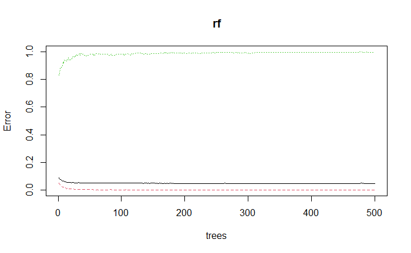

```r
plot(rf)
```

```r
confusionMatrix(predict(rf,test),test$stroke)
```

```
Confusion Matrix and Statistics

          Reference
Prediction  No Yes
       No  971  50
       Yes   1   0

               Accuracy : 0.9501
                 95% CI : (0.9349, 0.9626)
    No Information Rate : 0.9511
    P-Value [Acc > NIR] : 0.5942

                  Kappa : -0.0019

 Mcnemar's Test P-Value : 1.801e-11

            Sensitivity : 0.9990
            Specificity : 0.0000
         Pos Pred Value : 0.9510
         Neg Pred Value : 0.0000
             Prevalence : 0.9511
         Detection Rate : 0.9501
   Detection Prevalence : 0.9990
      Balanced Accuracy : 0.4995

       'Positive' Class : No
```